# Homework 1

Mari Sanders

2025-02-21

# A)

```r
training_dat <- read_csv("housing_training.csv")
test <- read_csv("housing_test.csv")
set.seed(10)
x <- model.matrix(Sale_Price ~ ., training_dat)[,-1]
y <- training_dat$Sale_Price
x2 <- model.matrix(Sale_Price ~ .,test)[, -1]
y2 <- test$Sale_Price
```

```r
set.seed(10)
ctrl1 <- trainControl(method = "cv", number = 10)
lasso.fit <- train(x,y,
                   data = training_dat,
                   method = "glmnet",
                   tuneGrid = expand.grid(alpha = 1,
                                          lambda = exp(seq(6, 0, length = 100))),
                   trControl = ctrl1)

lasso.fit$bestTune
```

```
##    alpha  lambda
## 69     1 61.6339
```

```r
lasso_predict <- predict(lasso.fit,newdata = model.matrix(Sale_Price ~ ., test)[,-1])
mse_lasso <- mean((lasso_predict - test$Sale_Price)^2)
rmse_lasso <- sqrt(mean((lasso_predict - test$Sale_Price)^2))

lasso_coef <- coef(lasso.fit$finalModel, s = lasso.fit$bestTune$lambda)
```

The lasso model fit with the best tune parameter has 23 parameters. The error is 4.4033543^{8} and the rmse is 2.0984171^{4}.

```r
set.seed(10)
minrmse <- min(lasso.fit$results$RMSE)
sdrmse <- sd(lasso.fit$results$RMSE)
rmse_1se <- minrmse + sdrmse

lambda_1se <- max(lasso.fit$results$lambda[lasso.fit$results$RMSE <= rmse_1se])

lasso.fit1se <- train(x,y,
                   data = training_dat,
                   method = "glmnet",
                   tuneGrid = expand.grid(alpha = 1,
                                          lambda = lambda_1se),
                   trControl = ctrl1)
lasso.fit1se$bestTune
```

```
##   alpha   lambda
## 1     1 194.9469
```

```r
lasso_predict1se <- predict(lasso.fit1se,newdata = model.matrix(Sale_Price ~ ., test)[,-1])


mse_lasso1se <- mean((lasso_predict - test$Sale_Price)^2)
rmse_lasso1se <- sqrt(mean((lasso_predict - test$Sale_Price)^2))

lasso_coef1se <- coef(lasso.fit1se$finalModel, s = lasso.fit1se$bestTune$lambda)
```

# B)

Yes 1se is applicable here because cross-validation results provide the error curves for multiple values of lambda. The 1SE rule selects the most regularized model within one standard error of the minimum cross-validation error, favoring simpler models.

```r
set.seed(10)
ctrl1 <- trainControl(method = "cv", number = 10)
enet.fit <- train(x, y,
                  data = training_dat,
                  method = "glmnet",
                  tuneGrid = expand.grid(alpha = seq(0, 1, length = 21),
                                         lambda = exp(seq(6,0, length = 100))),
                  trControl = ctrl1)
enet.fit$bestTune
```

```
##      alpha   lambda
## 1770  0.85 65.48481
```

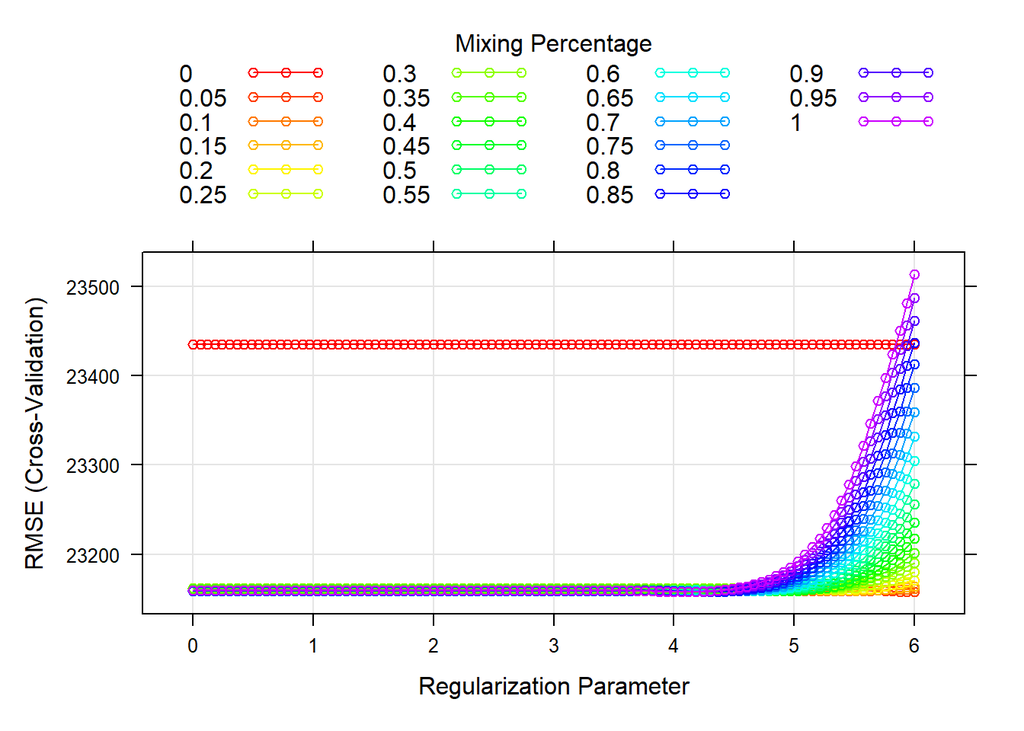

```r
enet_pred <-  predict(enet.fit,
                      newdata = model.matrix(Sale_Price ~ ., test)[,-1])
enet_coef <- coef(enet.fit$finalModel, s = enet.fit$bestTune$lambda)

mse_enet <- mean((enet_pred - test$Sale_Price)^2)
rmse_enet <- sqrt(mean((enet_pred - test$Sale_Price)^2))

myCol <- rainbow(25)
myPar <- list(superpose.symbol = list(col = myCol),
              superpose.line = list(col = myCol))

plot(enet.fit, par.settings = myPar, xTrans = log)
```

The tuning parameter for elastic net with minimum lambda is 0.85, 65.4848083. The model kept 23 parameters. The mse is 4.4083831^{8} and the rmse is 2.099615^{4}.

```r
minrmse <- min(enet.fit$results$RMSE)
sdrmse <- sd(enet.fit$results$RMSE)

rmse_1se <- minrmse + sdrmse

lambda_1se <- max(enet.fit$results$lambda[enet.fit$results$RMSE <= rmse_1se])
set.seed(10)
enet.fit_1se <- train(x, y,
                  data = training_dat,
                  method = "glmnet",
                  tuneGrid = expand.grid(alpha = enet.fit$bestTune$alpha,
                                         lambda = lambda_1se),
                  trControl = ctrl1)

enet_1se_pred <-  predict(enet.fit_1se,
                          newdata = model.matrix(Sale_Price ~ ., test)[,-1])

mse_enet1se <- mean((enet_1se_pred - test$Sale_Price)^2)
rmse_enet1se <- sqrt(mean((enet_1se_pred - test$Sale_Price)^2))

enet_coef1se <- coef(enet.fit_1se$finalModel, s = enet.fit_1se$bestTune$lambda)
```

The tuning parameter for elastic net with1SE RULE is 0.85, 403.4287935. The model kept 23 parameters. The mse is 4.2216072^{8} and the rmse is 2.054655^{4}.

# C)

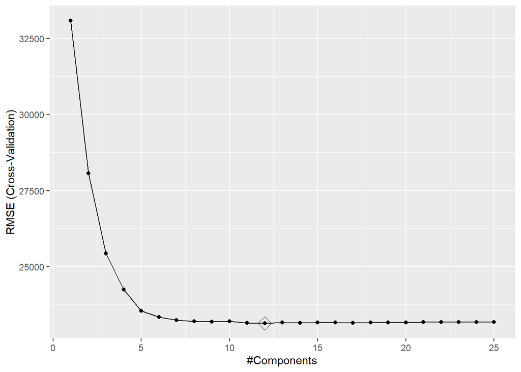

```r
set.seed(10)
pls_fit <- train(x, y,
                 method = "pls",
                 tuneGrid = data.frame(ncomp = 1:25),
                 trControl = ctrl1,
                 preProcess = c("center", "scale"))
predy2_pls2 <- predict(pls_fit, newdata = x2)

coefficients <- coef(pls_fit$finalModel, ncomp = pls_fit$bestTune$ncomp)

mse_pls <- mean((y2 - predy2_pls2)^2)

rmse_pls <- sqrt(mean((y2 - predy2_pls2)^2))


ggplot(pls_fit, highlight = TRUE)
```

There are 12 components included in this model. The mse is 4.4962272^{8} and the rmse is 2.1204309^{4}

# D)

```r
set.seed(10)
resamp <- resamples(list(enet = enet.fit, enet1se = enet.fit_1se, lasso = lasso.fit, lasso1se = lasso.fit1se))

summary(resamp)
```

```
##
## Call:
## summary.resamples(object = resamp)
##
## Models: enet, enet1se, lasso, lasso1se
## Number of resamples: 10
##
## MAE
##              Min.  1st Qu.   Median     Mean  3rd Qu.     Max. NA's
## enet     15064.40 15899.20 16591.19 16748.57 17567.78 18561.96    0
## enet1se  15219.62 15790.78 16850.80 16735.10 17516.48 18466.13    0
## lasso    15063.82 15891.84 16594.95 16746.00 17564.38 18553.75    0
## lasso1se 15103.37 15779.03 16687.41 16691.78 17531.57 18392.37    0
##
## RMSE
##              Min.  1st Qu.   Median     Mean  3rd Qu.     Max. NA's
## enet     19552.57 20932.91 23339.20 23158.16 24398.98 28681.88    0
## enet1se  19265.50 21220.73 23703.83 23436.87 24822.81 29416.03    0
## lasso    19539.42 20932.44 23341.92 23158.26 24405.30 28685.10    0
## lasso1se 19310.29 20994.17 23451.60 23229.89 24582.89 28924.81    0
##
## Rsquared
##               Min.   1st Qu.    Median      Mean   3rd Qu.      Max. NA's
## enet     0.8644025 0.8997390 0.9074714 0.9027221 0.9109504 0.9241505    0
## enet1se  0.8632826 0.8972124 0.9046572 0.9006280 0.9093198 0.9224979    0
## lasso    0.8644238 0.8997469 0.9074963 0.9027236 0.9109445 0.9241599    0
## lasso1se 0.8644571 0.8992763 0.9073483 0.9022181 0.9103074 0.9238081    0
```

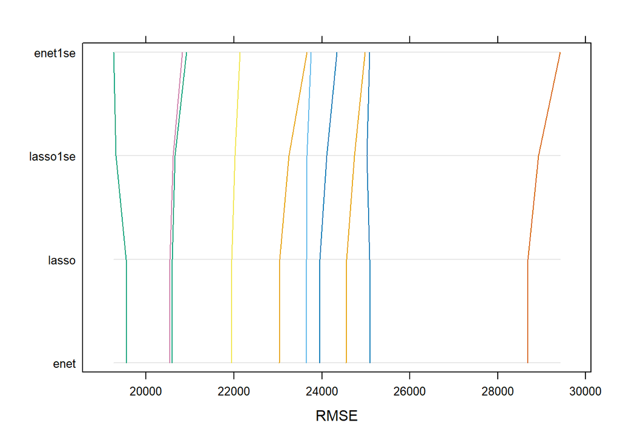

```r
parallelplot(resamp, metric = "RMSE")
```

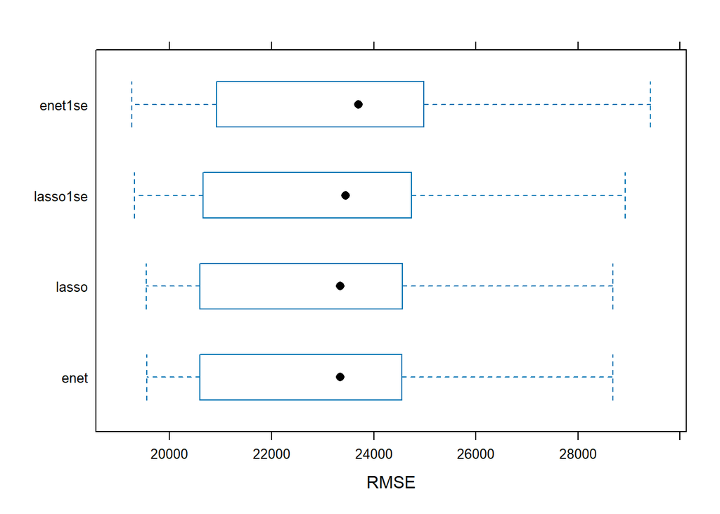

```r
bwplot(resamp, metric = "RMSE")
```

It seems like elastic net is the best model. It has the smallest median rmse when comparing all the models. However, elastic net and lasso are both fairly close in rmse.

```r
set.seed(10)
cv.lasso <- cv.glmnet(x, y,
                      alpha = 1,
                      lambda = exp(seq(6, 0, length = 100)))

cv.lasso$lambda.min
```

```
## [1] 33.62102
```

```r
lasso.fit$bestTune$lambda
```

```
## [1] 61.6339
```

Using `glmnet` to train the model, the selected tuning parameter is 33.6210216, while using `caret` got the result that the selected tuning parameter is 61.6339048. They are quite different in their results.